# Risk Factor Analysis

## Outcome Variable

**Outcome Variable:** ever_wasted

## Predictor Variables

**Intervention Variable:** feducyrs

**Adjustment Set:**

unadjusted

## Stratifying Variables

The analysis was stratified on these variable(s):

- agecat
- studyid
- country

## Data Summary

| agecat | studyid | country | feducyrs | ever_wasted | n_cell | n |
| --- | --- | --- | --- | --- | --- | --- |
| 0-24 months | ki0047075b-MAL-ED | BANGLADESH | High | 0 | 41 | 147 |
| 0-24 months | ki0047075b-MAL-ED | BANGLADESH | High | 1 | 13 | 147 |
| 0-24 months | ki0047075b-MAL-ED | BANGLADESH | Low | 0 | 23 | 147 |
| 0-24 months | ki0047075b-MAL-ED | BANGLADESH | Low | 1 | 16 | 147 |
| 0-24 months | ki0047075b-MAL-ED | BANGLADESH | Medium | 0 | 36 | 147 |
| 0-24 months | ki0047075b-MAL-ED | BANGLADESH | Medium | 1 | 18 | 147 |
| 0-24 months | ki0047075b-MAL-ED | INDIA | High | 0 | 22 | 147 |
| 0-24 months | ki0047075b-MAL-ED | INDIA | High | 1 | 22 | 147 |
| 0-24 months | ki0047075b-MAL-ED | INDIA | Low | 0 | 28 | 147 |
| 0-24 months | ki0047075b-MAL-ED | INDIA | Low | 1 | 31 | 147 |
| 0-24 months | ki0047075b-MAL-ED | INDIA | Medium | 0 | 27 | 147 |
| 0-24 months | ki0047075b-MAL-ED | INDIA | Medium | 1 | 17 | 147 |
| 0-24 months | ki0047075b-MAL-ED | NEPAL | High | 0 | 32 | 98 |
| 0-24 months | ki0047075b-MAL-ED | NEPAL | High | 1 | 10 | 98 |
| 0-24 months | ki0047075b-MAL-ED | NEPAL | Low | 0 | 18 | 98 |
| 0-24 months | ki0047075b-MAL-ED | NEPAL | Low | 1 | 10 | 98 |
| 0-24 months | ki0047075b-MAL-ED | NEPAL | Medium | 0 | 19 | 98 |
| 0-24 months | ki0047075b-MAL-ED | NEPAL | Medium | 1 | 9 | 98 |
| 0-24 months | ki0047075b-MAL-ED | PERU | High | 0 | 112 | 250 |
| 0-24 months | ki0047075b-MAL-ED | PERU | High | 1 | 8 | 250 |
| 0-24 months | ki0047075b-MAL-ED | PERU | Low | 0 | 65 | 250 |
| 0-24 months | ki0047075b-MAL-ED | PERU | Low | 1 | 4 | 250 |
| 0-24 months | ki0047075b-MAL-ED | PERU | Medium | 0 | 54 | 250 |
| 0-24 months | ki0047075b-MAL-ED | PERU | Medium | 1 | 7 | 250 |
| 0-24 months | ki0047075b-MAL-ED | SOUTH AFRICA | High | 0 | 36 | 110 |
| 0-24 months | ki0047075b-MAL-ED | SOUTH AFRICA | High | 1 | 7 | 110 |
| 0-24 months | ki0047075b-MAL-ED | SOUTH AFRICA | Low | 0 | 30 | 110 |
| 0-24 months | ki0047075b-MAL-ED | SOUTH AFRICA | Low | 1 | 7 | 110 |
| 0-24 months | ki0047075b-MAL-ED | SOUTH AFRICA | Medium | 0 | 23 | 110 |
| 0-24 months | ki0047075b-MAL-ED | SOUTH AFRICA | Medium | 1 | 7 | 110 |

[output cut: 330 more lines]

The following strata were considered:

- agecat: 0-24 months, studyid: ki0047075b-MAL-ED, country: BANGLADESH
- agecat: 0-24 months, studyid: ki0047075b-MAL-ED, country: INDIA
- agecat: 0-24 months, studyid: ki0047075b-MAL-ED, country: NEPAL
- agecat: 0-24 months, studyid: ki0047075b-MAL-ED, country: PERU
- agecat: 0-24 months, studyid: ki0047075b-MAL-ED, country: SOUTH AFRICA
- agecat: 0-24 months, studyid: ki0047075b-MAL-ED, country: TANZANIA, UNITED REPUBLIC OF
- agecat: 0-24 months, studyid: ki1000304b-SAS-CompFeed, country: INDIA
- agecat: 0-24 months, studyid: ki1000304b-SAS-FoodSuppl, country: INDIA
- agecat: 0-24 months, studyid: ki1017093b-PROVIDE, country: BANGLADESH
- agecat: 0-24 months, studyid: ki1017093c-NIH-Crypto, country: BANGLADESH
- agecat: 0-24 months, studyid: ki1066203-TanzaniaChild2, country: TANZANIA, UNITED REPUBLIC OF
- agecat: 0-24 months, studyid: ki1113344-GMS-Nepal, country: NEPAL
- agecat: 0-24 months, studyid: ki1119695-PROBIT, country: BELARUS
- agecat: 0-24 months, studyid: ki1126311-ZVITAMBO, country: ZIMBABWE
- agecat: 0-24 months, studyid: ki1135781-COHORTS, country: GUATEMALA
- agecat: 0-24 months, studyid: ki1135781-COHORTS, country: INDIA
- agecat: 0-24 months, studyid: ki1135781-COHORTS, country: PHILIPPINES
- agecat: 0-24 months, studyid: ki1148112-LCNI-5, country: MALAWI
- agecat: 0-24 months, studyid: kiGH5241-JiVitA-3, country: BANGLADESH
- agecat: 0-24 months, studyid: kiGH5241-JiVitA-4, country: BANGLADESH
- agecat: 0-6 months, studyid: ki0047075b-MAL-ED, country: BANGLADESH
- agecat: 0-6 months, studyid: ki0047075b-MAL-ED, country: INDIA
- agecat: 0-6 months, studyid: ki0047075b-MAL-ED, country: NEPAL
- agecat: 0-6 months, studyid: ki0047075b-MAL-ED, country: PERU
- agecat: 0-6 months, studyid: ki0047075b-MAL-ED, country: SOUTH AFRICA
- agecat: 0-6 months, studyid: ki0047075b-MAL-ED, country: TANZANIA, UNITED REPUBLIC OF
- agecat: 0-6 months, studyid: ki1000304b-SAS-CompFeed, country: INDIA
- agecat: 0-6 months, studyid: ki1000304b-SAS-FoodSuppl, country: INDIA
- agecat: 0-6 months, studyid: ki1017093b-PROVIDE, country: BANGLADESH
- agecat: 0-6 months, studyid: ki1017093c-NIH-Crypto, country: BANGLADESH
- agecat: 0-6 months, studyid: ki1066203-TanzaniaChild2, country: TANZANIA, UNITED REPUBLIC OF
- agecat: 0-6 months, studyid: ki1113344-GMS-Nepal, country: NEPAL
- agecat: 0-6 months, studyid: ki1119695-PROBIT, country: BELARUS
- agecat: 0-6 months, studyid: ki1126311-ZVITAMBO, country: ZIMBABWE
- agecat: 0-6 months, studyid: ki1135781-COHORTS, country: GUATEMALA
- agecat: 0-6 months, studyid: ki1135781-COHORTS, country: INDIA
- agecat: 0-6 months, studyid: ki1135781-COHORTS, country: PHILIPPINES
- agecat: 0-6 months, studyid: ki1148112-LCNI-5, country: MALAWI
- agecat: 0-6 months, studyid: kiGH5241-JiVitA-3, country: BANGLADESH
- agecat: 0-6 months, studyid: kiGH5241-JiVitA-4, country: BANGLADESH
- agecat: 6-24 months, studyid: ki0047075b-MAL-ED, country: BANGLADESH
- agecat: 6-24 months, studyid: ki0047075b-MAL-ED, country: INDIA
- agecat: 6-24 months, studyid: ki0047075b-MAL-ED, country: NEPAL
- agecat: 6-24 months, studyid: ki0047075b-MAL-ED, country: PERU
- agecat: 6-24 months, studyid: ki0047075b-MAL-ED, country: SOUTH AFRICA
- agecat: 6-24 months, studyid: ki0047075b-MAL-ED, country: TANZANIA, UNITED REPUBLIC OF
- agecat: 6-24 months, studyid: ki1000304b-SAS-CompFeed, country: INDIA
- agecat: 6-24 months, studyid: ki1000304b-SAS-FoodSuppl, country: INDIA
- agecat: 6-24 months, studyid: ki1017093b-PROVIDE, country: BANGLADESH
- agecat: 6-24 months, studyid: ki1017093c-NIH-Crypto, country: BANGLADESH
- agecat: 6-24 months, studyid: ki1066203-TanzaniaChild2, country: TANZANIA, UNITED REPUBLIC OF
- agecat: 6-24 months, studyid: ki1113344-GMS-Nepal, country: NEPAL
- agecat: 6-24 months, studyid: ki1119695-PROBIT, country: BELARUS
- agecat: 6-24 months, studyid: ki1126311-ZVITAMBO, country: ZIMBABWE
- agecat: 6-24 months, studyid: ki1135781-COHORTS, country: GUATEMALA
- agecat: 6-24 months, studyid: ki1135781-COHORTS, country: INDIA
- agecat: 6-24 months, studyid: ki1135781-COHORTS, country: PHILIPPINES
- agecat: 6-24 months, studyid: ki1148112-LCNI-5, country: MALAWI
- agecat: 6-24 months, studyid: kiGH5241-JiVitA-3, country: BANGLADESH
- agecat: 6-24 months, studyid: kiGH5241-JiVitA-4, country: BANGLADESH

### Dropped Strata

Some strata were dropped due to rare outcomes:

- agecat: 0-24 months, studyid: ki0047075b-MAL-ED, country: PERU
- agecat: 0-24 months, studyid: ki0047075b-MAL-ED, country: TANZANIA, UNITED REPUBLIC OF
- agecat: 0-6 months, studyid: ki0047075b-MAL-ED, country: NEPAL
- agecat: 0-6 months, studyid: ki0047075b-MAL-ED, country: PERU
- agecat: 0-6 months, studyid: ki0047075b-MAL-ED, country: SOUTH AFRICA
- agecat: 0-6 months, studyid: ki0047075b-MAL-ED, country: TANZANIA, UNITED REPUBLIC OF
- agecat: 0-6 months, studyid: ki1000304b-SAS-FoodSuppl, country: INDIA
- agecat: 0-6 months, studyid: ki1148112-LCNI-5, country: MALAWI
- agecat: 6-24 months, studyid: ki0047075b-MAL-ED, country: NEPAL
- agecat: 6-24 months, studyid: ki0047075b-MAL-ED, country: PERU
- agecat: 6-24 months, studyid: ki0047075b-MAL-ED, country: SOUTH AFRICA
- agecat: 6-24 months, studyid: ki0047075b-MAL-ED, country: TANZANIA, UNITED REPUBLIC OF

## Methods Detail

We’re interested in the causal parameters $E[Y_a]$ for all values of $a \in \mathcal{A}$. These parameters represent the mean outcome if, possibly contrary to fact, we intervened to set all units to have $A=a$. Under the randomization and positivity assumptions, these are identified by the statistical parameters $\psi_a=E_W[E_{Y|A,W}(Y|A=a,W)]$. In addition, we’re interested in the mean of $Y$, $E[Y]$ under no intervention (the observed mean). We will estimate these parameters by using SuperLearner to fit the relevant likelihood factors – $E_{Y|A,W}(Y|A=a,W)$ and $p(A=a|W)$, and then updating our likelihood fit using a joint TMLE.

For unadjusted analyses ($W=\{\}$), initial likelihoods were estimated using Lrnr_glm to estimate the simple $E(Y|A)$ and Lrnr_mean to estimate $p(A)$. For adjusted analyses, a small library containing Lrnr_glmnet, Lrnr_xgboost, and Lrnr_mean was used.

Having estimated these parameters, we will then use the delta method to estimate relative risks and attributable risks relative to a prespecified baseline level of $A$.

# Results Detail

## Results Plots

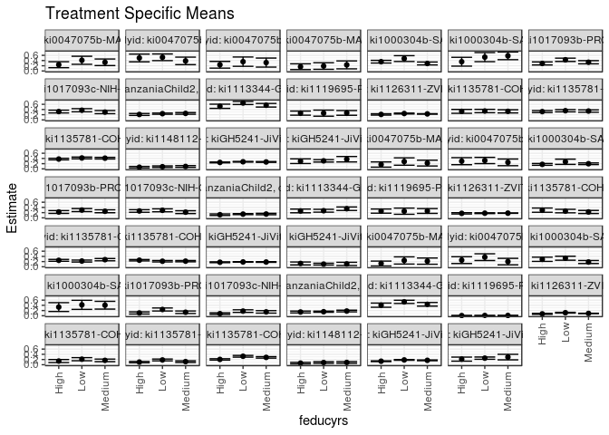

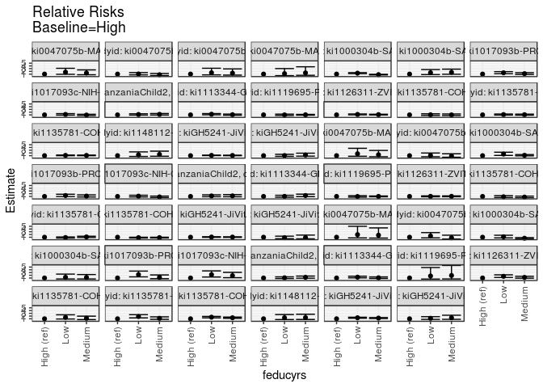

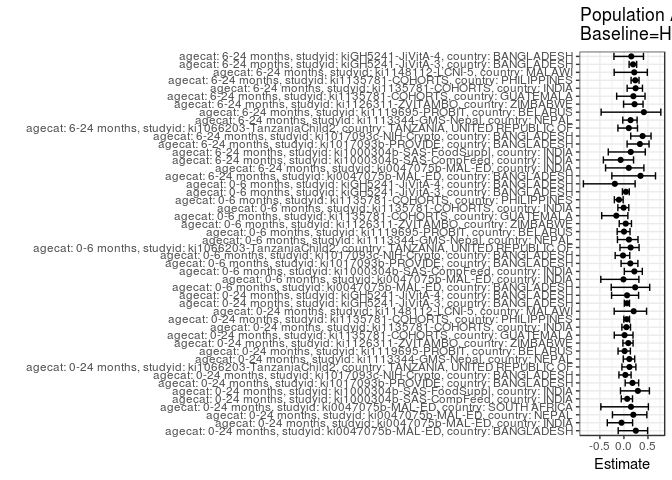

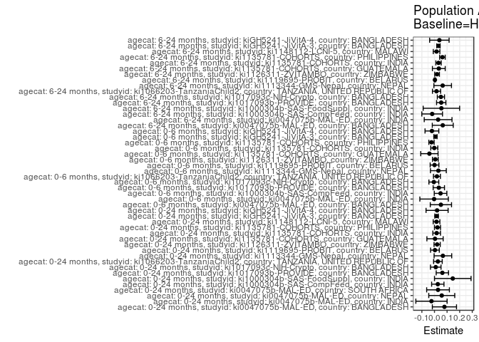

## Results Table

### Parameter: TSM

| agecat | studyid | country | intervention_level | baseline_level | estimate | ci_lower | ci_upper |
| --- | --- | --- | --- | --- | --- | --- | --- |
| 0-24 months | ki0047075b-MAL-ED | BANGLADESH | High | NA | 0.2407407 | 0.1263204 | 0.3551611 |
| 0-24 months | ki0047075b-MAL-ED | BANGLADESH | Low | NA | 0.4102564 | 0.2553543 | 0.5651585 |
| 0-24 months | ki0047075b-MAL-ED | BANGLADESH | Medium | NA | 0.3333333 | 0.2071717 | 0.4594949 |
| 0-24 months | ki0047075b-MAL-ED | INDIA | High | NA | 0.5000000 | 0.3517571 | 0.6482429 |
| 0-24 months | ki0047075b-MAL-ED | INDIA | Low | NA | 0.5254237 | 0.3975704 | 0.6532771 |
| 0-24 months | ki0047075b-MAL-ED | INDIA | Medium | NA | 0.3863636 | 0.2420001 | 0.5307272 |
| 0-24 months | ki0047075b-MAL-ED | NEPAL | High | NA | 0.2380952 | 0.1086231 | 0.3675674 |
| 0-24 months | ki0047075b-MAL-ED | NEPAL | Low | NA | 0.3571429 | 0.1787512 | 0.5355345 |
| 0-24 months | ki0047075b-MAL-ED | NEPAL | Medium | NA | 0.3214286 | 0.1475539 | 0.4953032 |
| 0-24 months | ki0047075b-MAL-ED | SOUTH AFRICA | High | NA | 0.1627907 | 0.0519425 | 0.2736389 |
| 0-24 months | ki0047075b-MAL-ED | SOUTH AFRICA | Low | NA | 0.1891892 | 0.0624128 | 0.3159655 |
| 0-24 months | ki0047075b-MAL-ED | SOUTH AFRICA | Medium | NA | 0.2333333 | 0.0812918 | 0.3853749 |
| 0-24 months | ki1000304b-SAS-CompFeed | INDIA | High | NA | 0.3553719 | 0.3037759 | 0.4069679 |
| 0-24 months | ki1000304b-SAS-CompFeed | INDIA | Low | NA | 0.4759358 | 0.3641976 | 0.5876740 |
| 0-24 months | ki1000304b-SAS-CompFeed | INDIA | Medium | NA | 0.2875817 | 0.2319283 | 0.3432351 |
| 0-24 months | ki1000304b-SAS-FoodSuppl | INDIA | High | NA | 0.3548387 | 0.1856096 | 0.5240679 |
| 0-24 months | ki1000304b-SAS-FoodSuppl | INDIA | Low | NA | 0.5312500 | 0.3575293 | 0.7049707 |
| 0-24 months | ki1000304b-SAS-FoodSuppl | INDIA | Medium | NA | 0.5813953 | 0.4332425 | 0.7295482 |
| 0-24 months | ki1017093b-PROVIDE | BANGLADESH | High | NA | 0.2887931 | 0.2304344 | 0.3471518 |
| 0-24 months | ki1017093b-PROVIDE | BANGLADESH | Low | NA | 0.4285714 | 0.3656552 | 0.4914876 |
| 0-24 months | ki1017093b-PROVIDE | BANGLADESH | Medium | NA | 0.3347826 | 0.2737506 | 0.3958146 |
| 0-24 months | ki1017093c-NIH-Crypto | BANGLADESH | High | NA | 0.3209459 | 0.2677281 | 0.3741638 |
| 0-24 months | ki1017093c-NIH-Crypto | BANGLADESH | Low | NA | 0.3719008 | 0.3109675 | 0.4328341 |
| 0-24 months | ki1017093c-NIH-Crypto | BANGLADESH | Medium | NA | 0.3000000 | 0.2394055 | 0.3605945 |
| 0-24 months | ki1066203-TanzaniaChild2 | TANZANIA, UNITED REPUBLIC OF | High | NA | 0.2093541 | 0.1717143 | 0.2469940 |
| 0-24 months | ki1066203-TanzaniaChild2 | TANZANIA, UNITED REPUBLIC OF | Low | NA | 0.2393701 | 0.2158976 | 0.2628426 |
| 0-24 months | ki1066203-TanzaniaChild2 | TANZANIA, UNITED REPUBLIC OF | Medium | NA | 0.2500000 | 0.2170576 | 0.2829424 |
| 0-24 months | ki1113344-GMS-Nepal | NEPAL | High | NA | 0.5238095 | 0.4430064 | 0.6046126 |
| 0-24 months | ki1113344-GMS-Nepal | NEPAL | Low | NA | 0.6498054 | 0.5914355 | 0.7081754 |
| 0-24 months | ki1113344-GMS-Nepal | NEPAL | Medium | NA | 0.5634518 | 0.4941378 | 0.6327658 |

[output cut: 114 more lines]

### Parameter: E(Y)

| agecat | studyid | country | intervention_level | baseline_level | estimate | ci_lower | ci_upper |
| --- | --- | --- | --- | --- | --- | --- | --- |
| 0-24 months | ki0047075b-MAL-ED | BANGLADESH | NA | NA | 0.3197279 | 0.2440789 | 0.3953769 |
| 0-24 months | ki0047075b-MAL-ED | INDIA | NA | NA | 0.4761905 | 0.3951786 | 0.5572024 |
| 0-24 months | ki0047075b-MAL-ED | NEPAL | NA | NA | 0.2959184 | 0.2050820 | 0.3867547 |
| 0-24 months | ki0047075b-MAL-ED | SOUTH AFRICA | NA | NA | 0.1909091 | 0.1171277 | 0.2646905 |
| 0-24 months | ki1000304b-SAS-CompFeed | INDIA | NA | NA | 0.3817787 | 0.3000427 | 0.4635148 |
| 0-24 months | ki1000304b-SAS-FoodSuppl | INDIA | NA | NA | 0.5000000 | 0.4043636 | 0.5956364 |
| 0-24 months | ki1017093b-PROVIDE | BANGLADESH | NA | NA | 0.3514286 | 0.3160364 | 0.3868207 |
| 0-24 months | ki1017093c-NIH-Crypto | BANGLADESH | NA | NA | 0.3311346 | 0.2976093 | 0.3646598 |
| 0-24 months | ki1066203-TanzaniaChild2 | TANZANIA, UNITED REPUBLIC OF | NA | NA | 0.2366765 | 0.2196074 | 0.2537455 |
| 0-24 months | ki1113344-GMS-Nepal | NEPAL | NA | NA | 0.5906822 | 0.5513381 | 0.6300263 |
| 0-24 months | ki1119695-PROBIT | BELARUS | NA | NA | 0.2648600 | 0.1706787 | 0.3590414 |
| 0-24 months | ki1126311-ZVITAMBO | ZIMBABWE | NA | NA | 0.2317505 | 0.2246488 | 0.2388522 |
| 0-24 months | ki1135781-COHORTS | GUATEMALA | NA | NA | 0.3333333 | 0.2953918 | 0.3712748 |
| 0-24 months | ki1135781-COHORTS | INDIA | NA | NA | 0.3365584 | 0.3122030 | 0.3609138 |
| 0-24 months | ki1135781-COHORTS | PHILIPPINES | NA | NA | 0.4013250 | 0.3833827 | 0.4192673 |
| 0-24 months | ki1148112-LCNI-5 | MALAWI | NA | NA | 0.0799508 | 0.0612962 | 0.0986054 |
| 0-24 months | kiGH5241-JiVitA-3 | BANGLADESH | NA | NA | 0.2640598 | 0.2549058 | 0.2732138 |
| 0-24 months | kiGH5241-JiVitA-4 | BANGLADESH | NA | NA | 0.3153266 | 0.2784039 | 0.3522494 |
| 0-6 months | ki0047075b-MAL-ED | BANGLADESH | NA | NA | 0.2176871 | 0.1507482 | 0.2846259 |
| 0-6 months | ki0047075b-MAL-ED | INDIA | NA | NA | 0.2925170 | 0.2187257 | 0.3663083 |
| 0-6 months | ki1000304b-SAS-CompFeed | INDIA | NA | NA | 0.2217391 | 0.1654429 | 0.2780353 |
| 0-6 months | ki1017093b-PROVIDE | BANGLADESH | NA | NA | 0.2585714 | 0.2261125 | 0.2910304 |
| 0-6 months | ki1017093c-NIH-Crypto | BANGLADESH | NA | NA | 0.2585752 | 0.2273844 | 0.2897660 |
| 0-6 months | ki1066203-TanzaniaChild2 | TANZANIA, UNITED REPUBLIC OF | NA | NA | 0.1397398 | 0.1258162 | 0.1536634 |
| 0-6 months | ki1113344-GMS-Nepal | NEPAL | NA | NA | 0.2961730 | 0.2596406 | 0.3327054 |
| 0-6 months | ki1119695-PROBIT | BELARUS | NA | NA | 0.2591409 | 0.1639775 | 0.3543043 |
| 0-6 months | ki1126311-ZVITAMBO | ZIMBABWE | NA | NA | 0.1794091 | 0.1729298 | 0.1858885 |
| 0-6 months | ki1135781-COHORTS | GUATEMALA | NA | NA | 0.2547368 | 0.2155121 | 0.2939615 |
| 0-6 months | ki1135781-COHORTS | INDIA | NA | NA | 0.2462950 | 0.2238538 | 0.2687361 |
| 0-6 months | ki1135781-COHORTS | PHILIPPINES | NA | NA | 0.2291594 | 0.2137721 | 0.2445467 |
| 0-6 months | kiGH5241-JiVitA-3 | BANGLADESH | NA | NA | 0.1822587 | 0.1741890 | 0.1903284 |
| 0-6 months | kiGH5241-JiVitA-4 | BANGLADESH | NA | NA | 0.1071913 | 0.0805964 | 0.1337862 |
| 6-24 months | ki0047075b-MAL-ED | BANGLADESH | NA | NA | 0.1908397 | 0.1232893 | 0.2583901 |
| 6-24 months | ki0047075b-MAL-ED | INDIA | NA | NA | 0.2846715 | 0.2088306 | 0.3605124 |
| 6-24 months | ki1000304b-SAS-CompFeed | INDIA | NA | NA | 0.2697674 | 0.2157680 | 0.3237669 |
| 6-24 months | ki1000304b-SAS-FoodSuppl | INDIA | NA | NA | 0.3883495 | 0.2937670 | 0.4829321 |
| 6-24 months | ki1017093b-PROVIDE | BANGLADESH | NA | NA | 0.1609756 | 0.1319065 | 0.1900447 |
| 6-24 months | ki1017093c-NIH-Crypto | BANGLADESH | NA | NA | 0.1315068 | 0.1069744 | 0.1560393 |
| 6-24 months | ki1066203-TanzaniaChild2 | TANZANIA, UNITED REPUBLIC OF | NA | NA | 0.1602787 | 0.1442326 | 0.1763249 |
| 6-24 months | ki1113344-GMS-Nepal | NEPAL | NA | NA | 0.4719864 | 0.4316361 | 0.5123367 |
| 6-24 months | ki1119695-PROBIT | BELARUS | NA | NA | 0.0084657 | 0.0067680 | 0.0101635 |
| 6-24 months | ki1126311-ZVITAMBO | ZIMBABWE | NA | NA | 0.0926247 | 0.0870490 | 0.0982004 |
| 6-24 months | ki1135781-COHORTS | GUATEMALA | NA | NA | 0.1752768 | 0.1432387 | 0.2073148 |
| 6-24 months | ki1135781-COHORTS | INDIA | NA | NA | 0.1323843 | 0.1146569 | 0.1501118 |
| 6-24 months | ki1135781-COHORTS | PHILIPPINES | NA | NA | 0.2666667 | 0.2498425 | 0.2834908 |
| 6-24 months | ki1148112-LCNI-5 | MALAWI | NA | NA | 0.0773067 | 0.0588111 | 0.0958024 |
| 6-24 months | kiGH5241-JiVitA-3 | BANGLADESH | NA | NA | 0.1653467 | 0.1559417 | 0.1747516 |
| 6-24 months | kiGH5241-JiVitA-4 | BANGLADESH | NA | NA | 0.2531486 | 0.2176598 | 0.2886375 |

### Parameter: RR

| agecat | studyid | country | intervention_level | baseline_level | estimate | ci_lower | ci_upper |
| --- | --- | --- | --- | --- | --- | --- | --- |
| 0-24 months | ki0047075b-MAL-ED | BANGLADESH | High | High | 1.0000000 | 1.0000000 | 1.0000000 |
| 0-24 months | ki0047075b-MAL-ED | BANGLADESH | Low | High | 1.7041420 | 0.9287226 | 3.1269833 |
| 0-24 months | ki0047075b-MAL-ED | BANGLADESH | Medium | High | 1.3846154 | 0.7541594 | 2.5421150 |
| 0-24 months | ki0047075b-MAL-ED | INDIA | High | High | 1.0000000 | 1.0000000 | 1.0000000 |
| 0-24 months | ki0047075b-MAL-ED | INDIA | Low | High | 1.0508475 | 0.7160831 | 1.5421121 |
| 0-24 months | ki0047075b-MAL-ED | INDIA | Medium | High | 0.7727273 | 0.4795940 | 1.2450269 |
| 0-24 months | ki0047075b-MAL-ED | NEPAL | High | High | 1.0000000 | 1.0000000 | 1.0000000 |
| 0-24 months | ki0047075b-MAL-ED | NEPAL | Low | High | 1.5000000 | 0.7168352 | 3.1387966 |
| 0-24 months | ki0047075b-MAL-ED | NEPAL | Medium | High | 1.3500000 | 0.6269331 | 2.9070086 |
| 0-24 months | ki0047075b-MAL-ED | SOUTH AFRICA | High | High | 1.0000000 | 1.0000000 | 1.0000000 |
| 0-24 months | ki0047075b-MAL-ED | SOUTH AFRICA | Low | High | 1.1621622 | 0.4470567 | 3.0211399 |
| 0-24 months | ki0047075b-MAL-ED | SOUTH AFRICA | Medium | High | 1.4333333 | 0.5585186 | 3.6783812 |
| 0-24 months | ki1000304b-SAS-CompFeed | INDIA | High | High | 1.0000000 | 1.0000000 | 1.0000000 |
| 0-24 months | ki1000304b-SAS-CompFeed | INDIA | Low | High | 1.3392613 | 1.1797207 | 1.5203775 |
| 0-24 months | ki1000304b-SAS-CompFeed | INDIA | Medium | High | 0.8092415 | 0.7068238 | 0.9264995 |
| 0-24 months | ki1000304b-SAS-FoodSuppl | INDIA | High | High | 1.0000000 | 1.0000000 | 1.0000000 |
| 0-24 months | ki1000304b-SAS-FoodSuppl | INDIA | Low | High | 1.4971591 | 0.8397182 | 2.6693304 |
| 0-24 months | ki1000304b-SAS-FoodSuppl | INDIA | Medium | High | 1.6384778 | 0.9541259 | 2.8136847 |
| 0-24 months | ki1017093b-PROVIDE | BANGLADESH | High | High | 1.0000000 | 1.0000000 | 1.0000000 |
| 0-24 months | ki1017093b-PROVIDE | BANGLADESH | Low | High | 1.4840085 | 1.1560081 | 1.9050742 |
| 0-24 months | ki1017093b-PROVIDE | BANGLADESH | Medium | High | 1.1592472 | 0.8830377 | 1.5218536 |
| 0-24 months | ki1017093c-NIH-Crypto | BANGLADESH | High | High | 1.0000000 | 1.0000000 | 1.0000000 |
| 0-24 months | ki1017093c-NIH-Crypto | BANGLADESH | Low | High | 1.1587647 | 0.9178206 | 1.4629609 |
| 0-24 months | ki1017093c-NIH-Crypto | BANGLADESH | Medium | High | 0.9347368 | 0.7197752 | 1.2138971 |
| 0-24 months | ki1066203-TanzaniaChild2 | TANZANIA, UNITED REPUBLIC OF | High | High | 1.0000000 | 1.0000000 | 1.0000000 |
| 0-24 months | ki1066203-TanzaniaChild2 | TANZANIA, UNITED REPUBLIC OF | Low | High | 1.1433741 | 0.9316394 | 1.4032300 |
| 0-24 months | ki1066203-TanzaniaChild2 | TANZANIA, UNITED REPUBLIC OF | Medium | High | 1.1941489 | 0.9555445 | 1.4923341 |
| 0-24 months | ki1113344-GMS-Nepal | NEPAL | High | High | 1.0000000 | 1.0000000 | 1.0000000 |
| 0-24 months | ki1113344-GMS-Nepal | NEPAL | Low | High | 1.2405377 | 1.0377311 | 1.4829792 |
| 0-24 months | ki1113344-GMS-Nepal | NEPAL | Medium | High | 1.0756807 | 0.8830692 | 1.3103038 |

[output cut: 114 more lines]

### Parameter: PAR

| agecat | studyid | country | intervention_level | baseline_level | estimate | ci_lower | ci_upper |
| --- | --- | --- | --- | --- | --- | --- | --- |
| 0-24 months | ki0047075b-MAL-ED | BANGLADESH | High | NA | 0.0789872 | -0.0169095 | 0.1748838 |
| 0-24 months | ki0047075b-MAL-ED | INDIA | High | NA | -0.0238095 | -0.1478386 | 0.1002195 |
| 0-24 months | ki0047075b-MAL-ED | NEPAL | High | NA | 0.0578231 | -0.0453561 | 0.1610024 |
| 0-24 months | ki0047075b-MAL-ED | SOUTH AFRICA | High | NA | 0.0281184 | -0.0620180 | 0.1182548 |
| 0-24 months | ki1000304b-SAS-CompFeed | INDIA | High | NA | 0.0264068 | -0.0225483 | 0.0753620 |
| 0-24 months | ki1000304b-SAS-FoodSuppl | INDIA | High | NA | 0.1451613 | 0.0001302 | 0.2901924 |
| 0-24 months | ki1017093b-PROVIDE | BANGLADESH | High | NA | 0.0626355 | 0.0136372 | 0.1116337 |
| 0-24 months | ki1017093c-NIH-Crypto | BANGLADESH | High | NA | 0.0101886 | -0.0315747 | 0.0519519 |
| 0-24 months | ki1066203-TanzaniaChild2 | TANZANIA, UNITED REPUBLIC OF | High | NA | 0.0273223 | -0.0069446 | 0.0615893 |
| 0-24 months | ki1113344-GMS-Nepal | NEPAL | High | NA | 0.0668727 | -0.0030068 | 0.1367522 |
| 0-24 months | ki1119695-PROBIT | BELARUS | High | NA | 0.0038159 | -0.0307710 | 0.0384027 |
| 0-24 months | ki1126311-ZVITAMBO | ZIMBABWE | High | NA | 0.0210650 | -0.0034349 | 0.0455648 |
| 0-24 months | ki1135781-COHORTS | GUATEMALA | High | NA | 0.0043860 | -0.0601723 | 0.0689443 |
| 0-24 months | ki1135781-COHORTS | INDIA | High | NA | 0.0173344 | -0.0128631 | 0.0475319 |
| 0-24 months | ki1135781-COHORTS | PHILIPPINES | High | NA | 0.0238931 | 0.0000055 | 0.0477806 |
| 0-24 months | ki1148112-LCNI-5 | MALAWI | High | NA | 0.0162058 | -0.0102108 | 0.0426223 |
| 0-24 months | kiGH5241-JiVitA-3 | BANGLADESH | High | NA | 0.0168583 | 0.0027732 | 0.0309434 |
| 0-24 months | kiGH5241-JiVitA-4 | BANGLADESH | High | NA | 0.0206838 | -0.0670019 | 0.1083694 |
| 0-6 months | ki0047075b-MAL-ED | BANGLADESH | High | NA | 0.0510204 | -0.0333601 | 0.1354009 |
| 0-6 months | ki0047075b-MAL-ED | INDIA | High | NA | -0.0029375 | -0.1160274 | 0.1101523 |
| 0-6 months | ki1000304b-SAS-CompFeed | INDIA | High | NA | 0.0481854 | -0.0017670 | 0.0981378 |
| 0-6 months | ki1017093b-PROVIDE | BANGLADESH | High | NA | 0.0344335 | -0.0105749 | 0.0794419 |
| 0-6 months | ki1017093c-NIH-Crypto | BANGLADESH | High | NA | -0.0049383 | -0.0439919 | 0.0341152 |
| 0-6 months | ki1066203-TanzaniaChild2 | TANZANIA, UNITED REPUBLIC OF | High | NA | 0.0194726 | -0.0080628 | 0.0470079 |
| 0-6 months | ki1113344-GMS-Nepal | NEPAL | High | NA | 0.0308669 | -0.0319096 | 0.0936434 |
| 0-6 months | ki1119695-PROBIT | BELARUS | High | NA | 0.0005063 | -0.0341402 | 0.0351529 |
| 0-6 months | ki1126311-ZVITAMBO | ZIMBABWE | High | NA | 0.0068203 | -0.0159283 | 0.0295690 |
| 0-6 months | ki1135781-COHORTS | GUATEMALA | High | NA | -0.0403451 | -0.1091237 | 0.0284334 |
| 0-6 months | ki1135781-COHORTS | INDIA | High | NA | -0.0014608 | -0.0293651 | 0.0264434 |
| 0-6 months | ki1135781-COHORTS | PHILIPPINES | High | NA | -0.0237589 | -0.0446531 | -0.0028647 |
| 0-6 months | kiGH5241-JiVitA-3 | BANGLADESH | High | NA | 0.0077348 | -0.0052219 | 0.0206915 |
| 0-6 months | kiGH5241-JiVitA-4 | BANGLADESH | High | NA | -0.0202597 | -0.0749167 | 0.0343974 |
| 6-24 months | ki0047075b-MAL-ED | BANGLADESH | High | NA | 0.0658397 | -0.0173452 | 0.1490246 |
| 6-24 months | ki0047075b-MAL-ED | INDIA | High | NA | 0.0288576 | -0.0812767 | 0.1389918 |
| 6-24 months | ki1000304b-SAS-CompFeed | INDIA | High | NA | -0.0183682 | -0.1004567 | 0.0637204 |
| 6-24 months | ki1000304b-SAS-FoodSuppl | INDIA | High | NA | 0.0550162 | -0.0896963 | 0.1997287 |
| 6-24 months | ki1017093b-PROVIDE | BANGLADESH | High | NA | 0.0534990 | 0.0164930 | 0.0905050 |
| 6-24 months | ki1017093c-NIH-Crypto | BANGLADESH | High | NA | 0.0510873 | 0.0225018 | 0.0796727 |
| 6-24 months | ki1066203-TanzaniaChild2 | TANZANIA, UNITED REPUBLIC OF | High | NA | 0.0162787 | -0.0161124 | 0.0486699 |
| 6-24 months | ki1113344-GMS-Nepal | NEPAL | High | NA | 0.0650899 | -0.0047621 | 0.1349418 |
| 6-24 months | ki1119695-PROBIT | BELARUS | High | NA | 0.0035112 | -0.0010984 | 0.0081207 |
| 6-24 months | ki1126311-ZVITAMBO | ZIMBABWE | High | NA | 0.0204889 | 0.0019072 | 0.0390706 |
| 6-24 months | ki1135781-COHORTS | GUATEMALA | High | NA | 0.0344317 | -0.0164366 | 0.0853000 |
| 6-24 months | ki1135781-COHORTS | INDIA | High | NA | 0.0322022 | 0.0109375 | 0.0534669 |
| 6-24 months | ki1135781-COHORTS | PHILIPPINES | High | NA | 0.0629830 | 0.0408737 | 0.0850924 |
| 6-24 months | ki1148112-LCNI-5 | MALAWI | High | NA | 0.0165780 | -0.0095602 | 0.0427162 |
| 6-24 months | kiGH5241-JiVitA-3 | BANGLADESH | High | NA | 0.0314884 | 0.0182692 | 0.0447076 |
| 6-24 months | kiGH5241-JiVitA-4 | BANGLADESH | High | NA | 0.0388629 | -0.0382665 | 0.1159923 |

### Parameter: PAF

| agecat | studyid | country | intervention_level | baseline_level | estimate | ci_lower | ci_upper |
| --- | --- | --- | --- | --- | --- | --- | --- |
| 0-24 months | ki0047075b-MAL-ED | BANGLADESH | High | NA | 0.2470449 | -0.1189307 | 0.4933186 |
| 0-24 months | ki0047075b-MAL-ED | INDIA | High | NA | -0.0500000 | -0.3457730 | 0.1807682 |
| 0-24 months | ki0047075b-MAL-ED | NEPAL | High | NA | 0.1954023 | -0.2384488 | 0.4772675 |
| 0-24 months | ki0047075b-MAL-ED | SOUTH AFRICA | High | NA | 0.1472868 | -0.4798679 | 0.5086590 |
| 0-24 months | ki1000304b-SAS-CompFeed | INDIA | High | NA | 0.0691679 | -0.0551571 | 0.1788442 |
| 0-24 months | ki1000304b-SAS-FoodSuppl | INDIA | High | NA | 0.2903226 | -0.0713379 | 0.5298943 |
| 0-24 months | ki1017093b-PROVIDE | BANGLADESH | High | NA | 0.1782310 | 0.0264289 | 0.3063637 |
| 0-24 months | ki1017093c-NIH-Crypto | BANGLADESH | High | NA | 0.0307688 | -0.1039248 | 0.1490280 |
| 0-24 months | ki1066203-TanzaniaChild2 | TANZANIA, UNITED REPUBLIC OF | High | NA | 0.1154417 | -0.0417379 | 0.2489057 |
| 0-24 months | ki1113344-GMS-Nepal | NEPAL | High | NA | 0.1132126 | -0.0137722 | 0.2242914 |
| 0-24 months | ki1119695-PROBIT | BELARUS | High | NA | 0.0144070 | -0.1220131 | 0.1342405 |
| 0-24 months | ki1126311-ZVITAMBO | ZIMBABWE | High | NA | 0.0908952 | -0.0211948 | 0.1906817 |
| 0-24 months | ki1135781-COHORTS | GUATEMALA | High | NA | 0.0131579 | -0.2008287 | 0.1890123 |
| 0-24 months | ki1135781-COHORTS | INDIA | High | NA | 0.0515049 | -0.0425973 | 0.1371137 |
| 0-24 months | ki1135781-COHORTS | PHILIPPINES | High | NA | 0.0595354 | -0.0019267 | 0.1172273 |
| 0-24 months | ki1148112-LCNI-5 | MALAWI | High | NA | 0.2026969 | -0.2022753 | 0.4712590 |
| 0-24 months | kiGH5241-JiVitA-3 | BANGLADESH | High | NA | 0.0638428 | 0.0089734 | 0.1156744 |
| 0-24 months | kiGH5241-JiVitA-4 | BANGLADESH | High | NA | 0.0655948 | -0.2566561 | 0.3052092 |
| 0-6 months | ki0047075b-MAL-ED | BANGLADESH | High | NA | 0.2343750 | -0.2638627 | 0.5361983 |
| 0-6 months | ki0047075b-MAL-ED | INDIA | High | NA | -0.0100423 | -0.4810578 | 0.3111779 |
| 0-6 months | ki1000304b-SAS-CompFeed | INDIA | High | NA | 0.2173068 | 0.0088687 | 0.3819096 |
| 0-6 months | ki1017093b-PROVIDE | BANGLADESH | High | NA | 0.1331682 | -0.0592168 | 0.2906105 |
| 0-6 months | ki1017093c-NIH-Crypto | BANGLADESH | High | NA | -0.0190982 | -0.1818918 | 0.1212723 |
| 0-6 months | ki1066203-TanzaniaChild2 | TANZANIA, UNITED REPUBLIC OF | High | NA | 0.1393487 | -0.0816372 | 0.3151857 |
| 0-6 months | ki1113344-GMS-Nepal | NEPAL | High | NA | 0.1042192 | -0.1347954 | 0.2928917 |
| 0-6 months | ki1119695-PROBIT | BELARUS | High | NA | 0.0019539 | -0.1406518 | 0.1267309 |
| 0-6 months | ki1126311-ZVITAMBO | ZIMBABWE | High | NA | 0.0380154 | -0.0975133 | 0.1568081 |
| 0-6 months | ki1135781-COHORTS | GUATEMALA | High | NA | -0.1583796 | -0.4621488 | 0.0822799 |
| 0-6 months | ki1135781-COHORTS | INDIA | High | NA | -0.0059313 | -0.1258536 | 0.1012173 |
| 0-6 months | ki1135781-COHORTS | PHILIPPINES | High | NA | -0.1036784 | -0.1986289 | -0.0162496 |
| 0-6 months | kiGH5241-JiVitA-3 | BANGLADESH | High | NA | 0.0424386 | -0.0313191 | 0.1109213 |
| 0-6 months | kiGH5241-JiVitA-4 | BANGLADESH | High | NA | -0.1890047 | -0.8426009 | 0.2327518 |
| 6-24 months | ki0047075b-MAL-ED | BANGLADESH | High | NA | 0.3450000 | -0.2511462 | 0.6570944 |
| 6-24 months | ki0047075b-MAL-ED | INDIA | High | NA | 0.1013715 | -0.3817356 | 0.4155660 |
| 6-24 months | ki1000304b-SAS-CompFeed | INDIA | High | NA | -0.0680888 | -0.4267418 | 0.2004063 |
| 6-24 months | ki1000304b-SAS-FoodSuppl | INDIA | High | NA | 0.1416667 | -0.3251717 | 0.4440448 |
| 6-24 months | ki1017093b-PROVIDE | BANGLADESH | High | NA | 0.3323421 | 0.0662098 | 0.5226261 |
| 6-24 months | ki1017093c-NIH-Crypto | BANGLADESH | High | NA | 0.3884761 | 0.1417210 | 0.5642892 |
| 6-24 months | ki1066203-TanzaniaChild2 | TANZANIA, UNITED REPUBLIC OF | High | NA | 0.1015652 | -0.1248504 | 0.2824067 |
| 6-24 months | ki1113344-GMS-Nepal | NEPAL | High | NA | 0.1379062 | -0.0238534 | 0.2741093 |
| 6-24 months | ki1119695-PROBIT | BELARUS | High | NA | 0.4147494 | -0.4738095 | 0.7675967 |
| 6-24 months | ki1126311-ZVITAMBO | ZIMBABWE | High | NA | 0.2212035 | -0.0071359 | 0.3977734 |
| 6-24 months | ki1135781-COHORTS | GUATEMALA | High | NA | 0.1964418 | -0.1510037 | 0.4390063 |
| 6-24 months | ki1135781-COHORTS | INDIA | High | NA | 0.2432477 | 0.0674593 | 0.3858992 |
| 6-24 months | ki1135781-COHORTS | PHILIPPINES | High | NA | 0.2361863 | 0.1492748 | 0.3142189 |
| 6-24 months | ki1148112-LCNI-5 | MALAWI | High | NA | 0.2144443 | -0.2028818 | 0.4869839 |
| 6-24 months | kiGH5241-JiVitA-3 | BANGLADESH | High | NA | 0.1904386 | 0.1082043 | 0.2650899 |
| 6-24 months | kiGH5241-JiVitA-4 | BANGLADESH | High | NA | 0.1535181 | -0.2073613 | 0.4065310 |